# Analysis of Different Predictive Models for Prediction of Aromatic Rings in SRC Kinase Inhibitors

### Analysis of Variables, Distributions, and Correlations- Visualization

```r
# Analysis of Variables and Distributions
# analyze variables and the way that they are distributed through histograms and scatterplots.

# install tidyverse
install.packages("tidyverse")
library(tidyverse)
```

#### Histogram Visualization of Variables

We use the histograms to understand how the data is distributed for each feature. This can potentially provide insight into the way we want to build the model and the importance of each feature.

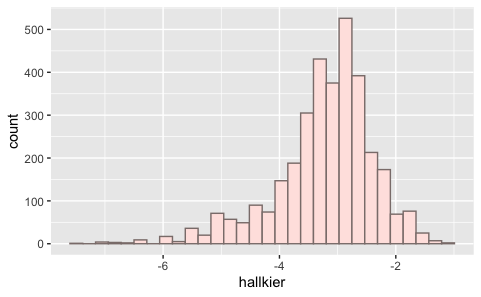

```r
# create histogram plots for feature set and outcome variable to understand distributions

# Hallkier Count Histogram
ggplot(src_kin_2, aes(x=hallkier))+
  geom_histogram(color="mistyrose4", fill="mistyrose")
```

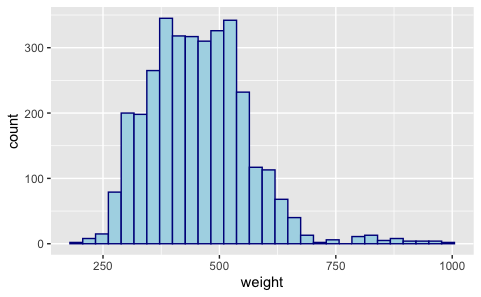

```r
# Weight Histogram
ggplot(src_kin_2, aes(x=weight))+
  geom_histogram(color="darkblue", fill="lightblue")
```

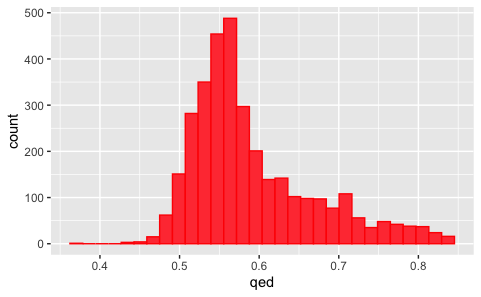

```r
# QED values Histogram
ggplot(src_kin_2, aes(x=qed))+
  geom_histogram(color="red1", fill="brown1")
```

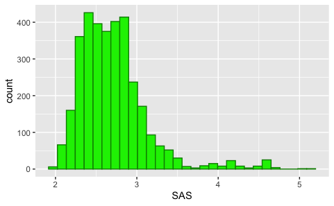

```r
# SAS Values Histogram
ggplot(src_kin_2, aes(x=SAS))+
  geom_histogram(color="green4", fill="green2")
```

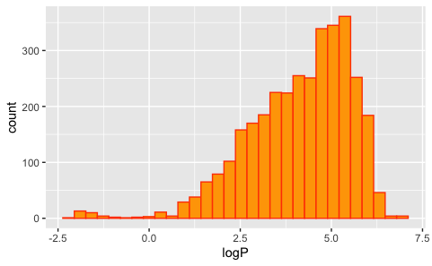

```r
# logP Values Histogram
ggplot(src_kin_2, aes(x=logP))+
  geom_histogram(color="orangered1", fill="orange")
```

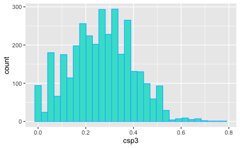

```r
# CSP3 Values Histogram
ggplot(src_kin_2, aes(x=csp3))+
  geom_histogram(color="deepskyblue1", fill="turquoise")
```

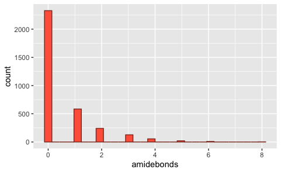

```r
# Amide Bond Values Histogram
ggplot(src_kin_2, aes(x=amidebonds))+
  geom_histogram(color="tomato4", fill="tomato1")
```

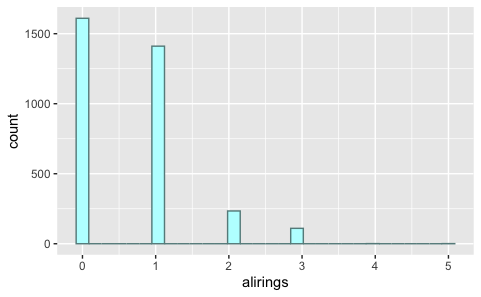

```r
# Ali Rings Count Histogram
ggplot(src_kin_2, aes(x=alirings))+
  geom_histogram(color="paleturquoise4", fill="paleturquoise1")
```

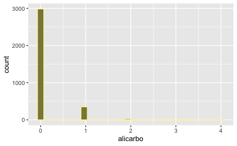

```r
# Ali Carbo Count Histogram
ggplot(src_kin_2, aes(x=alicarbo))+
  geom_histogram(color="khaki1", fill="khaki4")
```

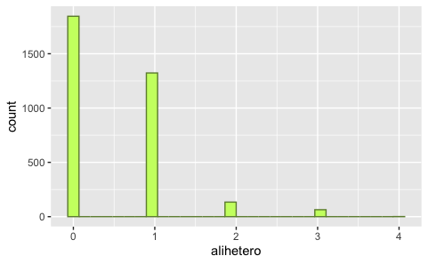

```r
# Ali Hetero Count Histogram
ggplot(src_kin_2, aes(x=alihetero))+
  geom_histogram(color="darkolivegreen4", fill="darkolivegreen1")
```

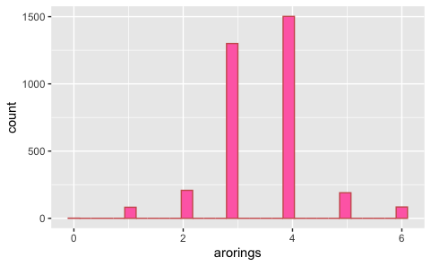

```r
# Aro Ring Count Histogram
ggplot(src_kin_2, aes(x=arorings))+
  geom_histogram(color="indianred", fill="hotpink1")
```

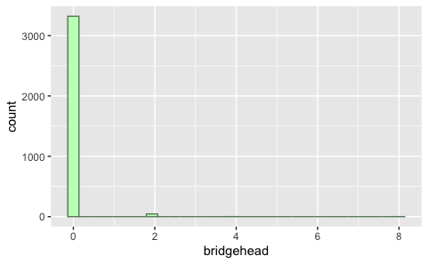

```r
# Bridgehead Count Histogram
ggplot(src_kin_2, aes(x=bridgehead))+
  geom_histogram(color="darkseagreen4", fill="darkseagreen1")
```

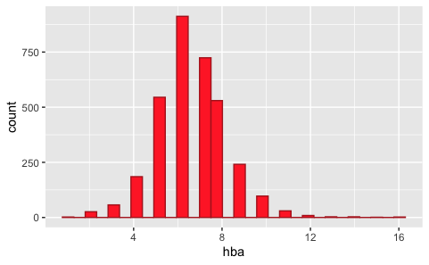

```r
# HBA Count Histogram
ggplot(src_kin_2, aes(x=hba))+
  geom_histogram(color="firebrick", fill="firebrick1")
```

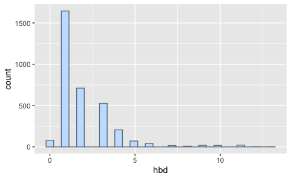

```r
# HBD Count Histogram
ggplot(src_kin_2, aes(x=hbd))+
  geom_histogram(color="slategray", fill="slategray1")
```

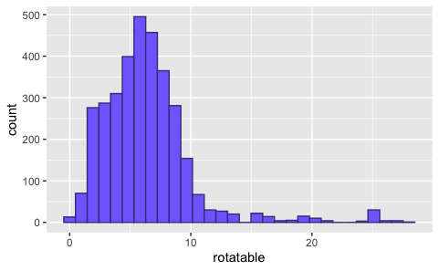

```r
ggplot(src_kin_2, aes(x=rotatable))+
  geom_histogram(color="slateblue4", fill="slateblue1")
```

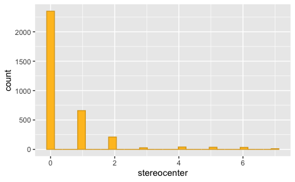

```r
# Stereocenter Count Histogram
ggplot(src_kin_2, aes(x=stereocenter))+
  geom_histogram(color="goldenrod", fill="goldenrod1")
```

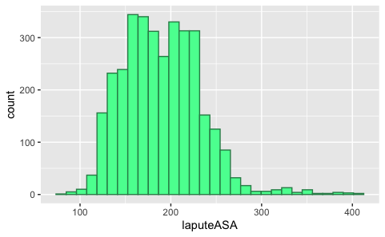

```r
# laputeASA Count Histograms
ggplot(src_kin_2, aes(x=laputeASA))+
  geom_histogram(color="seagreen4", fill="seagreen1")
```

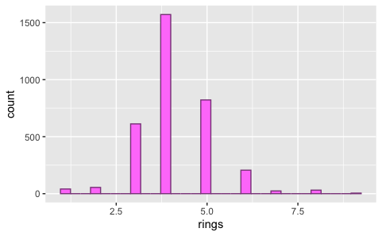

```r
# Rings count Histogram -> outcome variable
ggplot(src_kin_2, aes(x=rings))+
  geom_histogram(color="orchid4", fill="orchid1")
```

#### Scatterplot Visualization of Covariates to Predictor Variable

The scatter plot visualization helps in understanding how each variable is correlated to the predictor variable. In some ways we can understand what type and how big of a role each variable plays in the prediction and potentially define the correlation.

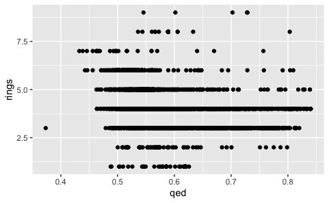

```r
# understand relationship between covariates and predictor variable which is rings. use ggplot for plots to understand for further analysis
# when forming models

ggplot(data = src_kin_2) +
  geom_point(mapping = aes(x = qed, y = rings))
```

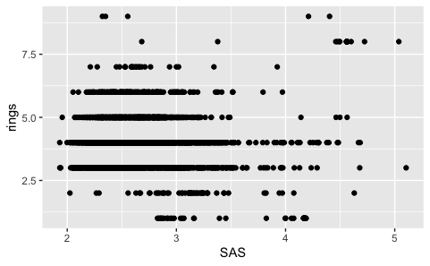

```r
ggplot(data = src_kin_2) +
  geom_point(mapping = aes(x = SAS, y = rings))
```

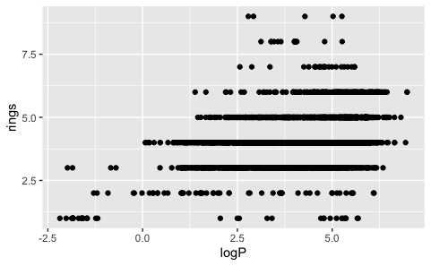

```r
ggplot(data = src_kin_2) +
  geom_point(mapping = aes(x = logP, y = rings))
```

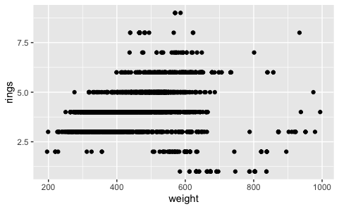

```r
ggplot(data = src_kin_2) +
  geom_point(mapping = aes(x = weight, y = rings))
```

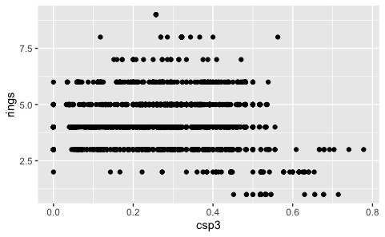

```r
ggplot(data = src_kin_2) +
  geom_point(mapping = aes(x = csp3, y = rings))
```

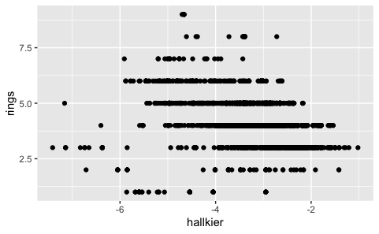

```r
ggplot(data = src_kin_2) +
  geom_point(mapping = aes(x = hallkier, y = rings))
```

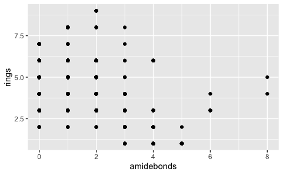

```r
ggplot(data = src_kin_2) +
  geom_point(mapping = aes(x = amidebonds, y = rings))
```

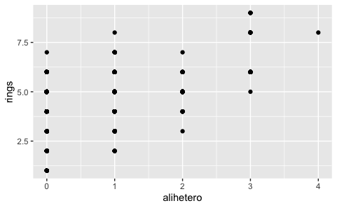

```r
ggplot(data = src_kin_2) +
  geom_point(mapping = aes(x = alihetero, y = rings))
```

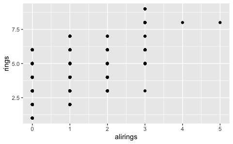

```r
ggplot(data = src_kin_2) +
  geom_point(mapping = aes(x = alirings, y = rings))
```

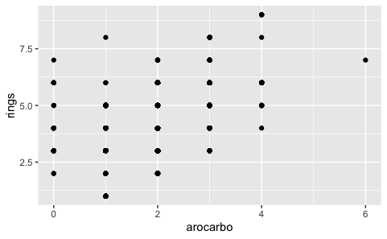

```r
ggplot(data = src_kin_2) +
  geom_point(mapping = aes(x = arocarbo, y = rings))
```

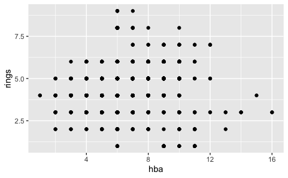

```r
ggplot(data = src_kin_2) +
  geom_point(mapping = aes(x = hba, y = rings))
```